# Gün 5: Final ödevi

2025-09-19

Bu final projesinde, kursumuzda şimdiye kadar öğrendiğimiz kavramların çoğunu pratikte uygulayacağız. Aynı zamanda aşılamanın nasıl modellendiğini keşfetmek ve halk sağlığı acil durumlarında kaynak tahsisini dikkatli bir şekilde düşünmek için iyi bir fırsat. Bu final egzersizi işbirliği içinde çözülmesi ve günün sonunda daha geniş gruba geri sunulması amaçlanmıştır. Tek bir doğru cevap bulunmamakla birlikte, uygulama sırasında tek bir doğru eylem yolunun bulunduğu belirli noktalar vardır.

## 1. Gastroenterit salgını

Bölgenizde geçtiğimiz ay boyunca gelişen bir gastroenterit (GE) salgınının salgın analiz danışma ekibini yönetiyorsunuz. İndeks vaka, kusma, ishal ve 2 gün süren dehidratasyona maruz kalan 66 yaşındaki bir erkek hastanın büyük bir genel hastanede bildirilmesi ile ortaya çıktı. Benzer semptomların sonraki vakaları aynı hastanede ve bölgedeki diğer hastanelerde bildirilmiştir. Salgın araştırma ekibi hastanelerde meydana gelen vakaları kaydetmiş ve mümkün olduğunda dışkı ve kan örnekleri toplamıştır.

Size vaka serileri içeren küçük bir veri seti (aşağıya bakın) verilmiştir. Verilerinizi yükleyin ve grafik haline getirin.

```
## here() starts at C:/Users/jfv09/Dropbox/Code/Git/ide-modelling-R-ankara-turkish
```

[figure not shown]

```r
#gerekli paketleri yükle
library(ggplot2)
library(reshape2)
library(dplyr)
library(here)
library(socialmixr)
data<-read.csv(here("data","daily_GE_data.csv"))
data$t<-as.factor(data$Days)
# Bar grafiği
ggplot(data, aes(x=t, y=Cases)) +
  geom_bar(stat = "identity", width=0.2)+
  ylab("bildirilen GE vakaları") +
  xlab("gün")
```

## 2. NoV bulaşması için salgın verilerine bir model kalibre edin

Bir modelleyici olarak sizden mevcut salgın verilerini kullanarak farklı yaş gruplarında NoV bulaşması için bir model oluşturmanız ve kalibre etmeniz, salgının simülasyonla yeniden üretilip üretilemeyeceğini görmek için kullanmanız istenmektedir. Norovirüs hakkındaki mevcut bilgilerin sistematik bir incelemesi şu ana noktaları bulmuştur: İnsan Norovirüsü esas olarak küçük çocuklar ve yaşlılar arasında gastroenterit salgınlarına neden olur. Semptomatik bir vakanın ortalama 2 gün süresi vardır ve 1 günden fazla olmayan kuluçka süresi bulunur. Semptomatik dönemden sonra bireyler dışkılarında yaklaşık 15 gün boyunca virüs atabilirler, bu da onları hafif derecede bulaştırıcı yapar ancak tamamen semptomatik vakadan çok daha az.

Salgının toplam boyutunun çok daha büyük olması beklenmektedir, çünkü GE vakalarının sadece bir kısmı bildirilmekte veya hastaneye gitmektedir. Bu durum hızla kötüleşebilen yaşlılar için daha da belirgindir. Bu nedenle çıktınızı daha önce tahmin edilmiş toplum vakası/bildirilen vaka oranlarını (aşağıdaki kodda) kullanarak düzeltmelisiniz.

Aşağıda Norovirüs bulaşmasının SEIAR stokastik, yaş yapılı modeli için kod bulunmaktadır. Model, önceki uygulamalarda kullandığımız Odin paketi kullanılarak programlanmıştır.

- Görev 1: Aşağıdaki kodu okuyarak model yapısının nasıl göründüğünü yorumlamaya çalışın. Bir şema çizin.
- Görev 2: Aşağıdaki kodda soru işareti (??) simgesi ile işaretlenmiş veri boşluklarını doldurun. Verileri çıkarmak ve anlamlı oranlara dönüştürmek için yukarıdaki metni dikkatli bir şekilde okuyun.

```r
# ODIN paketini yükle
library(odin)

## NoV modeli oluştur
seiar_generator <- odin::odin({

  dt <- user(1)
  initial(time) <- 0
  update(time) <- (step + 1) * dt


  ## Bölmeler arası genel geçişler için temel denklemler:
  update(V_tot) <- V_tot + sum(n_SV) + sum(n_RV) - sum(n_VS) - sum(n_VVA)
  update(S_tot) <- S_tot + sum(n_VS) + sum(n_RS) - sum(n_SE) - sum(n_SV)
  update(E_tot) <- E_tot + sum(n_SE)  - sum(n_EI)
  update(I_tot) <- I_tot + sum(n_EI) - sum(n_IA) - sum(n_deathI)
  update(A_tot) <- A_tot + sum(n_IA) - sum(n_AR) - sum(n_deathA)
  update(VA_tot) <- VA_tot +  sum(n_VVA) - sum(n_VAR) - sum(n_deathVA)
  update(R_tot) <- R_tot + sum(n_AR) + sum(n_VAR) - sum(n_RS) - sum(n_RV)

  ## Yaş grubuna göre bölmeler arası geçiş denklemleri
  update(V[]) <- V[i] + n_SV[i] + n_RV[i] - n_VS[i] - n_VVA[i]
  update(S[]) <- S[i] + n_VS[i] + n_RS[i] - n_SE[i] - n_SV[i]
  update(E[]) <- E[i] + n_SE[i] - n_EI[i]
  update(I[]) <- I[i] + n_EI[i] - n_IA[i] - n_deathI[i]
  update(A[]) <- A[i] + n_IA[i] - n_AR[i] - n_deathA[i]
  update(VA[]) <- VA[i] + n_VVA[i] - n_VAR[i] - n_deathVA[i]
  update(R[]) <- R[i] + n_AR[i] + n_VAR[i] - n_RS[i] - n_RV[i]

  ## Analiz için model çıktıları
  update(cum_vaccines[]) <-cum_vaccines[i]+ n_SV[i] + n_RV[i]
  update(new_cases[]) <- n_EI[i]
  update(cum_cases[]) <- cum_cases[i] + n_EI[i]
  update(cum_deaths[]) <- cum_deaths[i] + n_deathI[i] + n_deathA[i] + n_deathVA[i]

  update(cum_vaccines_all) <- cum_vaccines_all+ sum(n_SV) + sum(n_RV)
  update(new_cases_all) <- sum(n_EI)
  update(cum_cases_all) <- cum_cases_all + sum(n_EI)
  update(new_reported_all) <- sum(new_reports)
  update(cum_deaths_all) <- cum_deaths_all + sum(n_deathI) + sum(n_deathA) + sum(n_deathVA)

  new_reports[]<- n_EI[i] * 1/rep_ratio[i]
  dim(new_reports)<-N_age


  ## Bireysel geçiş olasılıkları:
  p_VS[] <- 1 - exp(-delta * dt)  # V'den S'ye
  p_SE[] <- 1 - exp(-lambda[i] * dt) # S'den E'ye
  p_EI   <- 1 - exp(-epsilon * dt) # E'den I'ya
  p_IA   <- 1 - exp(-theta * dt) # I'dan A'ya
  p_AR   <- 1 - exp(-sigma * dt) # A'dan R'ye
  p_RS   <- 1 - exp(-tau * dt) # R'den S'ye
  p_vacc[] <- 1 - exp(-vac_imm*vac_cov[i] * dt)# aşılama
  p_noromu[]<- 1 - exp(- ((p_IA+p_AR) * cfr[i]/(1-cfr[i])) * dt)# aşılama

  ## Bulaş kuvveti
  m[, ] <- user() # yaş yapılı temas matrisi
  s_ij[, ] <- m[i, j] * (I[j] + (A[j] * rho )+ (A[j] * rho * vac_eff) )
  lambda[] <- beta * sum(s_ij[i, ])

  ## Bölmeler arasında değişen sayılar için binomial dağılımlardan çekimler:

  # V'den çıkanlar
  n_VS[] <- rbinom(V[i],  p_VS[i])
  n_VVA[] <- rbinom(V[i]-n_VS[i], p_SE[i] * (1-vac_eff))

  # S'den çıkanlar
  n_SE[] <- rbinom(S[i], p_SE[i])
  n_SV[] <- rbinom(S[i]-n_SE[i], if (step > t_vacc) p_vacc[i] else 0)

  # E'den çıkanlar
  n_EI[] <- rbinom(E[i], p_EI)

  # I'dan çıkanlar
  n_IA[] <- rbinom(I[i], p_IA)
  n_deathI[]<-rbinom(I[i] - n_IA[i], p_noromu[i])

  # A'dan çıkanlar
  n_AR[] <- rbinom(A[i], p_AR)
  n_deathA[]<-rbinom(A[i] - n_AR[i], p_noromu[i])

  # VA'dan çıkanlar
  n_VAR[] <- rbinom(VA[i], p_AR)
  n_deathVA[]<-rbinom(VA[i] - n_VAR[i], p_noromu[i]* (1-vac_eff))

  # R'den çıkanlar
  n_RS[] <- rbinom(R[i], p_RS)
  n_RV[] <- rbinom(R[i] - n_RS[i], if (step > t_vacc) p_vacc[i] else 0)

  ## Başlangıç durumları:
  initial(V_tot) <- sum(V_ini)
  initial(S_tot) <- sum(S_ini)
  initial(E_tot) <- sum(E_ini)
  initial(I_tot) <- sum(I_ini)
  initial(A_tot) <- sum(A_ini)
  initial(VA_tot) <- sum(VA_ini)
  initial(R_tot) <- sum(R_ini)

  initial(V[]) <- V_ini[i]
  initial(S[]) <- S_ini[i]
  initial(E[]) <- E_ini[i]
  initial(I[]) <- I_ini[i]
  initial(A[]) <- A_ini[i]
  initial(VA[]) <- VA_ini[i]
  initial(R[]) <- R_ini[i]
  initial(cum_vaccines[]) <- 0
  initial(new_cases[]) <- 0
  initial(cum_cases[]) <- 0
  initial(cum_deaths[]) <- 0
  initial(cum_vaccines_all) <- 0
  initial(new_cases_all) <- 0
  initial(cum_cases_all) <- 0
  initial(new_reported_all)<-0
  initial(cum_deaths_all) <- 0


  ## Kullanıcı tanımlı durumlar - parantez içinde varsayılanlar:
  V_ini[] <- user()
  S_ini[] <- user()
  E_ini[] <- user()
  I_ini[] <- user()
  A_ini[] <- user()
  VA_ini[] <- user()
  R_ini[] <- user()

  ########## Model parametreleri (parantez içindeki değerler varsayılan değerlerdir)

  beta <- user(0.003)   # bulaş katsayısı
  delta <- user(1/365)  # aşı bağışıklık süresi (~1 yıl)
  epsilon <- user( ?? ) #######<------------------------ Kuluçka süresini doldurun
  theta <- user(??)     #######<------------------------ Semptom süresini doldurun
  sigma <- user(??)     #######<------------------------ Asemptomatik atılım süresini doldurun
  tau   <- user(1/365)  # bağışıklık süresi
  rho   <- user(0.05)   # göreceli bulaştırıcılık asemptomatik
  cfr[]  <- user()      # Yaşa göre Noro CFR
  vac_eff<-user(0.9)    # Bulaş için aşı etkinliği
  vac_cov[]<-user()     # yaş grubuna göre aşı kapsamı
  vac_imm  <- user(1/5) # aşı serokonversiyon zamanı (gün)
  t_vacc   <- user(2)   # vaka 0'dan sonra aşı tanıtımına kadar geçen günler
  rep_ratio[]  <-user() # bildirilen vaka başına toplumda vaka sayısı

  # dizilerin boyutları
  N_age <- user()
  dim(V_ini) <- N_age
  dim(S_ini) <- N_age
  dim(E_ini) <- N_age
  dim(I_ini) <- N_age
  dim(A_ini) <- N_age
  dim(VA_ini) <- N_age
  dim(R_ini) <- N_age
  dim(vac_cov)<-N_age
  dim(cfr)  <- N_age
  dim(rep_ratio)  <- N_age
  dim(V) <- N_age
  dim(S) <- N_age
  dim(E) <- N_age
  dim(I) <- N_age
  dim(A) <- N_age
  dim(VA) <- N_age
  dim(R) <- N_age
  dim(cum_vaccines) <- N_age
  dim(new_cases) <- N_age
  dim(cum_cases) <- N_age
  dim(cum_deaths) <- N_age
  dim(n_SV) <- N_age
  dim(n_RV) <- N_age
  dim(n_VS) <- N_age
  dim(n_VVA) <- N_age
  dim(n_VAR) <- N_age
  dim(n_SE) <- N_age
  dim(n_EI) <- N_age
  dim(n_IA) <- N_age
  dim(n_AR) <- N_age
  dim(n_RS) <- N_age
  dim(n_deathI)<-N_age
  dim(n_deathA)<-N_age
  dim(n_deathVA)<-N_age
  dim(p_VS) <- N_age
  dim(p_SE) <- N_age
  dim(p_vacc)<-N_age
  dim(p_noromu)<-N_age
  dim(m) <- c(N_age, N_age)
  dim(s_ij) <- c(N_age, N_age)
  dim(lambda) <- N_age
}, verbose = FALSE)
```

Yaş yapılı bir model uygulamak için birkaç bilgiye ihtiyacımız var:

1. Yaş grupları: Yaş yapısının tanımlanması gerekir. İlgi alanındaki grupların 0-4, 5-14, 15-64 ve 65+ olmasına karar verilmiştir.
2. Yaşa özgü temas oranları. Yaş gruplarını uygularsak, modeli belirli yaş grubundaki bireylerin diğer yaş gruplarıyla etkili temas kurma (yani bulaş için yeterli temas) oranları ile bilgilendirmemiz gerekir. Buna temas matrisi denir. Bu uygulamada yaygın olarak kullanılan bir temas matrisi kaynağı olan POLYMOD’u kullanıyoruz. [Buraya](https://journals.plos.org/ploscompbiol/article?id=10.1371/journal.pcbi.1005697) bakın. POLYMOD 152’den fazla ülke için temas matrisi projekte eder. Türkiye için tahmin edilen bir matris kullanıyoruz. İlgi alanındaki yaş gruplarıyla eşleşecek şekilde uyarlanmıştır. Bu temas matrisi, i yaşındaki bir bireyin bir günde j yaşındaki başka bir bireyle kurduğu ortalama temas sayısını içerir. Aşağıdaki kodu kontrol edin ve matrisin grafiğini yorumlamaya çalışın.

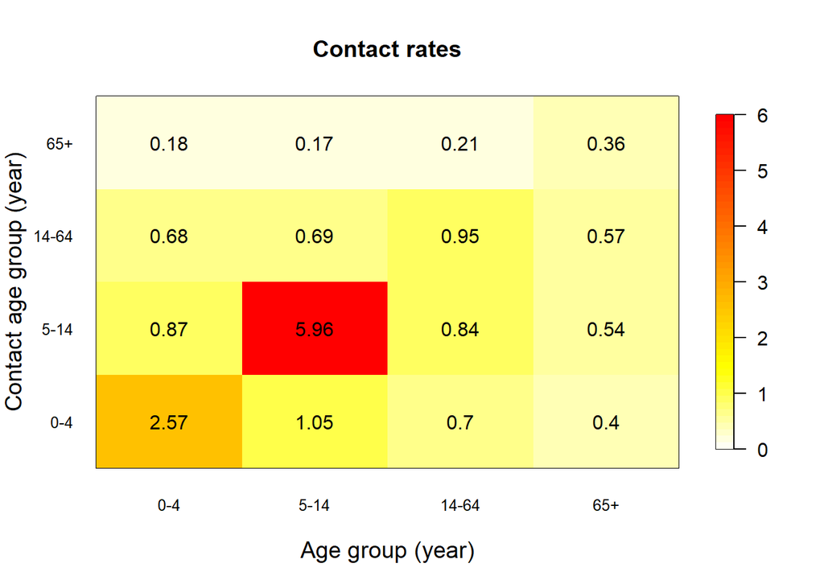

```r
# Temas matrisini yükle
cmat<-read.csv(here("data","contact_TUR.csv"))

contact_matrix<-as.matrix(cmat) # Matris nesnesine dönüştür
rownames(contact_matrix)<-c("0-4","5-14","14-64","65+") # yaş etiketleri ekle
colnames(contact_matrix)<-c("0-4","5-14","14-64","65+") # yaş etiketleri ekle

# temas matrisini çizmek için matrix_plot kullan
matrix_plot(contact_matrix)
```

Yukarıdaki grafiği dikkatli bir şekilde inceleyin ve bunun hastalık bulaşması için ne anlama geldiğini düşünün.

Sonraki bölümde salgın verilerine *en iyi uyan beta* değerlerini bulmaya çalışacaksınız.

```r
# Rastgele sayılar için tohum
set.seed(1)

# İlgilenilen X bölgesinde toplam nüfusu tanımla
N<-68000

n_age<- 4 # yaş grubu sayısı

# Nüfus parametreleri
            #  0-4  5-14  15-64  65+
pop_distr<- c(0.16, 0.17, 0.63,  0.04) # Nüfus yaş dağılımı
pop <- round(N * pop_distr)

# Temas matrisini işle: matrisin simetrik olduğundan emin olmamız gerekiyor
# yani talep edilen temaslar sunulan temaslar ile eşit
cmat_sym<-((cmat+t(cmat))/2)

# Bulaş formülüne girdi olacak kişi başına temas oranını bul
# yani her gruptaki nüfus büyüklüğüne göre düzeltildi
transmission <- as.matrix(cmat_sym )/
  rep(c(t(pop)), each = ncol(cmat_sym))

# Noro Vaka ölüm oranı (bkz. Lindsay et al https://bmcinfectdis.biomedcentral.com/articles/10.1186/s12879-015-1168-5))

# Yaş grubuna göre NoV CFR
     #  0-4  5-14  15-64  65+
mu<-c( 0.04, 0.01, 0.03, 0.63)/1000

# Bildirilen oranlar: hastane salgınında bildirilen vaka başına toplumda vaka sayısı
# (Varsayım: bu kesin değil ama örn. Birleşik Krallık'ta bildirilen her vaka için
# toplumda ~280 bulunabileceği tahmin ediliyor)

          #  0-4  5-14  15-64  65+
rep_ratio<-c(40,  65,   30,    15)
```

Şimdi modeli çalıştırmak için tüm parçalara sahip olduğunuza göre

1. Salgında bildirilen vakaları en iyi şekilde fit eden *beta* değerlerini keşfetmek için aşağıdaki kodu kullanın (ipucu: 0.5 ile 2 arasındaki değerleri keşfetmeyi deneyin)
2. En iyi uyum gösteren grafiğinizi sunum için kaydedin ve *beta* değerinizi saklayın. Buna daha sonra ihtiyacınız olacak

```r
# SEIAR nesnesini çağır
seiar0 <- seiar_generator$new(
  V_ini = c(1:n_age)*0,
  S_ini = as.numeric(round(N*pop_distr - c(1,0,0,0))),
  E_ini = c(1:n_age)*0,
  I_ini = c(1,0,0,0),
  A_ini = c(1:n_age)*0,
  VA_ini = c(1:n_age)*0,
  R_ini = c(1:n_age)*0,
  N_age = n_age,
  cfr= mu,
  m=transmission,
  rep_ratio=rep_ratio,
  vac_cov= c(0,0,0,0),
  beta = 0 ## <================ Aşağıdaki grafikte en iyi uyan farklı beta değerlerini deneyin
)


# Çoklu çalıştırmalar (100)
t_end<- 365 * 2 # sim zamanı (2 yıl)

# Modeli çalıştır
seiar0_100 <- seiar0$run(0:t_end, replicate = 100)

# Değişken indeksi
idx<-rownames(seiar0_100[1,,])

# Bildirilen vakalar vs veri : Doğru betayı bulana kadar bu kodda yineleme yapın
t_id<-which(idx=="time")
id<- which(idx=="new_reported_all")
mean <- rowMeans(seiar0_100[, id,])
matplot(seiar0_100[, t_id,],seiar0_100[, id,],
        xlab = "Günler",
        ylab = "Bildirilen GE vaka sayısı",
        type = "l", lty = 1, col="grey",
        xlim=c(0,30),
        ylim=c(0,max(data$Cases)*1.2))
lines(seiar0_100[, 1,1],mean,col="purple")
points(data$Days+5, data$Cases, col = "red", pch = 19)
```

İyi uyan bir *beta* değeri bulduğunuza göre, kalibre edilmiş modelinizin bazı bulaş dinamiklerini keşfedin.

Salgın sırasında NoV vakalarının toplam simüle edilmiş insidansını çizmek için aşağıdaki kodu çalıştırın (bildirme oranlarıyla düzeltilmemiş)

```r
# Toplum insidansı
id<- which(idx=="new_cases_all")
mean <- rowMeans(seiar0_100[, id,])
matplot(seiar0_100[, t_id,],seiar0_100[, id,],
        xlab = "Günler",
        ylab = "Vaka sayısı",
        type = "l", lty = 1, col="grey",
        xlim=c(0,30))
lines(seiar0_100[, 1,1],mean,col="purple")
```

NoV’den modellenmiş kümülatif ölümler

```r
# Kümülatif NoV ölümleri
id<- which(idx=="cum_deaths_all")
mean <- rowMeans(seiar0_100[, id,])
matplot(seiar0_100[, t_id,],seiar0_100[, id,],
        xlab = "Günler",
        ylab = "kümülatif ölüm sayısı",
        type = "l", lty = 1, col="grey",
        xlim=c(0,365))
lines(seiar0_100[, 1,1],mean,col="purple")
```

Yaşa göre yığılmış ölümler

```r
# Yaşa göre yığılmış ölümler

time <- (seiar0_100[, t_id,1])
t<-rep(time,4)
age <-  c(rep(c("0_4") , length(time)),
          rep(c("5_14") , length(time)),
          rep(c("15_64") , length(time)),
          rep(c("65+") , length(time)))
deaths <- c( rowMeans(seiar0_100[,which(idx=="cum_deaths[1]") ,]),
             rowMeans(seiar0_100[,which(idx=="cum_deaths[2]") ,]),
             rowMeans(seiar0_100[,which(idx=="cum_deaths[3]") ,]),
             rowMeans(seiar0_100[,which(idx=="cum_deaths[4]") ,]))
df <- data.frame(t,age,deaths)

# Yaşa göre zaman içinde yığılmış kümülatif ölümler
ggplot(df, aes(fill=age, y=deaths, x=t)) +
  geom_bar(position="stack", stat="identity")+
  xlab("günler")+ ylab("Kümülatif Ölümler")


# Yaşa göre zaman içinde göreceli yığılmış kümülatif ölümler
ggplot(df, aes(fill=age, y=deaths, x=t)) +
  geom_bar(position="fill", stat="identity")+
  xlab("günler")+ ylab("Kümülatif Ölümlerin Oranı")
```

Yaş grubuna göre simüle edilmiş NoV vakaları

```r
# yaşa göre vakalar
time <- (seiar0_100[, t_id,1])
t<-rep(time,4)
age <-  c(rep(c("0_4") , length(time)),
          rep(c("5_14") , length(time)),
          rep(c("15_64") , length(time)),
          rep(c("65+") , length(time)))
cases <- c( 1000*(rowMeans(seiar0_100[,which(idx=="cum_cases[1]") ,])/pop[1]),
            1000*( rowMeans(seiar0_100[,which(idx=="cum_cases[2]") ,])/pop[2]),
            1000*(rowMeans(seiar0_100[,which(idx=="cum_cases[3]") ,])/pop[3]),
            1000*(rowMeans(seiar0_100[,which(idx=="cum_cases[4]") ,]))/pop[4])
df <- data.frame(t,age,cases)

ggplot(df,aes(color=age, y=cases, x=t)) +
  geom_line() +
  xlab("günler")+ ylab("1000 nüfus başına kümülatif insidans oranı")
```

Bu grafikleri dikkatli bir şekilde inceleyin ve anlamaya çalışın

1. hangi gruplar en çok etkileniyor?
2. Hangi yaş grubu salgını büyüklük açısından yönlendiriyor?

Bir sonraki adıma geçmeden önce. Bir sonraki bölümde temel tahminleriniz olarak kullanacağınız yararlı model çıktısı oluşturmak için aşağıdaki kodu çalıştırın.

```r
# Analiz çıktısı

id<- which(idx=="cum_deaths_all")
base_deaths <- mean(seiar0_100[365 ,id, ]) # bir yıl sonra NoV'den kümülatif ölümler
print(base_deaths)

id<- which(idx=="cum_cases_all")
base_cases <- mean(seiar0_100[365 ,id, ]) # bir yıl sonra NoV'den kümülatif vakalar
print(base_cases)

id<- which(idx=="cum_vaccines_all")
base_doses <- mean(seiar0_100[365 ,id, ]) # bir yıl sonra kümülatif aşı dozu (0)
print(base_doses)
```

## 3. Yeni bir aşı mevcut hale geliyor

Projenin bu bölümünde sizden potansiyel aşılama senaryolarını değerlendirmeniz ve kaynaklarınızı kullanmanın en verimli yoluna karar vermeniz istenmektedir.

Norovirüs için aşı geliştirme hattında şu anda faz III denemelerinde en az üç potansiyel formülasyon bulunmaktadır. Bu formülasyonlar inaktive virüs, mRNA ve VLP (virüs benzeri partiküller) türü aşıları içerir. Hepsi GII.4 genogrubunu ve GI.3 veya GI.1 genogrupunu içerir. GII.4 dünyadaki çoğu epideminin nedenidir. Basitlik için bu egzersizde genogrupları veya varyantları modellemiyoruz.

Size iki aşı formülasyonunun mevcut hale geldiği bildirildi:

- **NoVax Aşısı:** Ön immünojenite çalışmalarında iyi antikor (AB) yanıtı göstermiş olup, ilk dozdan yaklaşık **5 gün** sonra zirve yapmaktadır. Faz III denemeleri **%75**’lik hayal kırıklığı yaratan bir etkinlik göstermiştir
- **Vomax Aşısı:** Bu aşı **%92**’lik çok yüksek bir etkinlik göstermiştir, ancak üretim yöntemi nedeniyle immünolojik yanıt çok daha yavaştır ve koruyucu AB değerlerine ulaşmak yaklaşık **12 gün** sürmektedir

Bölgenizde kontamine suların yeni salgınlarının tekrar oluşması beklenmektedir ve sizden modelinizi kullanarak potansiyel bir aşının benzer bir salgında vakaları nasıl önleyebileceğini ve hayat kurtarabileceğini geriye dönük olarak değerlendirmeniz istenmektedir.

Bunun için NoVax veya Vomax aşısı ile farklı yaşa özgü aşı kapsamını keşfettiğiniz üç aşılama senaryosu önermeniz gerekir. Her senaryo için şunları tahmin edeceksiniz:

- Bir yıl boyunca önlenen toplam vakalar (temel duruma göre)
- Bir yıl boyunca önlenen toplam ölümler (temel duruma göre)
- Verilen toplam doz
- Önlenen vaka ve ölüm başına doz

Aşağıda üç senaryonun her birini oluşturmak ve etki göstergelerini tahmin etmek için gerekli kodu göreceksiniz.

Cevabınızı bulana kadar bu senaryolar arasında gerektiği kadar yineleme yapın.

*İpucu: bulaş dinamiklerini ve hangi grupların insidans ve mortaliteden en çok etkilendiğini dikkatli bir şekilde düşünün*

Sonunda grubunuz şunları sunacağınız 5 dakikalık (maksimum) bir sunum hazırlayacak:

1. veriye en iyi model uyumu
2. Üç analiz senaryosu ve etkisi içeren tablo
3. Sadece bir senaryo seçin ve gerekçenizi epidemiyolojik terimlerle verin

# Senaryo 1

```r
## Senaryo 1

seiar1 <- seiar_generator$new(
  V_ini = c(1:n_age)*0,
  S_ini = as.numeric(round(N*pop_distr - c(1,0,0,0))),
  E_ini = c(1:n_age)*0,
  I_ini = c(1,0,0,0),
  A_ini = c(1:n_age)*0,
  VA_ini = c(1:n_age)*0,
  R_ini = c(1:n_age)*0,
  N_age = n_age,
  cfr= mu,
  m=transmission,
  rep_ratio=rep_ratio,
  vac_cov= c(0,0,0,0),## <------- Farklı yaş gruplarında aşılama kapsamını seçin (0-1 arası)
  vac_eff = 0,       ## <------- Aşı etkinliğini doldurun (NoVax veya Vomax)
  vac_imm = 0,       ## <------- AB korunmasına geçiş oranını doldurun (NoVax veya Vomax) (1/gün)
  beta = 0           ## <--------2. bölümden en iyi uyumlu betanızla doldurun
)

# Modeli çalıştır
seiar1_100 <- seiar1$run(0:t_end, replicate = 100)

# Analiz çıktısı
id<- which(idx=="cum_deaths_all")
sc1_deaths <- mean(seiar1_100[365 ,id, ]) ## 1 yıl sonra kümülatif ölümler

id<- which(idx=="cum_cases_all")
sc1_cases <- mean(seiar1_100[365 ,id, ]) ## 1 yıl sonra kümülatif vakalar

id<- which(idx=="cum_vaccines_all")
sc1_doses <- mean(seiar1_100[365 ,id, ]) ## 1 yıl sonra kümülatif doz

sc1_avdeaths<-base_deaths-sc1_deaths ## 1 yıl sonra önlenen ölümler

sc1_avcases<-base_cases-sc1_cases    ## 1 yıl sonra önlenen vakalar

dose_per_avdeath1<- sc1_doses/sc1_avdeaths ## 1 ölümü önlemek için gereken doz sayısı

dose_per_avcase1<- sc1_doses/sc1_avcases ## 1 vakayı önlemek için gereken doz sayısı


print(paste("1 yıl sonra kümülatif ölümler",sc1_deaths))
print(paste("1 yıl sonra kümülatif vakalar",sc1_cases))
print(paste("1 yıl sonra kümülatif doz",sc1_doses))

print(paste("1 yıl sonra önlenen ölümler",sc1_avdeaths))
print(paste("1 yıl sonra önlenen vakalar",sc1_avcases))
print(paste("1 ölümü önlemek için gereken doz sayısı",dose_per_avdeath1))
print(paste("1 vakayı önlemek için gereken doz sayısı",dose_per_avcase1))
```

# Senaryo 2

```r
## Senaryo 2

seiar2 <- seiar_generator$new(
  V_ini = c(1:n_age)*0,
  S_ini = as.numeric(round(N*pop_distr - c(1,0,0,0))),
  E_ini = c(1:n_age)*0,
  I_ini = c(1,0,0,0),
  A_ini = c(1:n_age)*0,
  VA_ini = c(1:n_age)*0,
  R_ini = c(1:n_age)*0,
  N_age = n_age,
  cfr= mu,
  m=transmission,
  rep_ratio=rep_ratio,
  vac_cov= c(0,0,0,0),## <------- Farklı yaş gruplarında aşılama kapsamını seçin (0-1 arası)
  vac_eff = 0,       ## <------- Aşı etkinliğini doldurun (NoVax veya Vomax)
  vac_imm = 0,       ## <------- AB korunmasına geçiş oranını doldurun (NoVax veya Vomax) (1/gün)
  beta = 0           ## <--------2. bölümden en iyi uyumlu betanızla doldurun
)

# Modeli çalıştır
seiar2_100 <- seiar2$run(0:t_end, replicate = 100)

# Analiz çıktısı
id<- which(idx=="cum_deaths_all")
sc2_deaths <- mean(seiar2_100[365 ,id, ]) ## 1 yıl sonra kümülatif ölümler

id<- which(idx=="cum_cases_all")
sc2_cases <- mean(seiar2_100[365 ,id, ]) ## 1 yıl sonra kümülatif vakalar

id<- which(idx=="cum_vaccines_all")
sc2_doses <- mean(seiar2_100[365 ,id, ]) ## 1 yıl sonra kümülatif doz

sc2_avdeaths<-base_deaths-sc2_deaths ## 1 yıl sonra önlenen ölümler

sc2_avcases<-base_cases-sc2_cases    ## 1 yıl sonra önlenen vakalar

dose_per_avdeath2<- sc2_doses/sc2_avdeaths ## 1 ölümü önlemek için gereken doz sayısı

dose_per_avcase2<- sc2_doses/sc2_avcases ## 1 vakayı önlemek için gereken doz sayısı

print(paste("1 yıl sonra kümülatif ölümler",sc2_deaths))
print(paste("1 yıl sonra kümülatif vakalar",sc2_cases))
print(paste("1 yıl sonra kümülatif doz",sc2_doses))

print(paste("1 yıl sonra önlenen ölümler",sc2_avdeaths))
print(paste("1 yıl sonra önlenen vakalar",sc2_avcases))
print(paste("1 ölümü önlemek için gereken doz sayısı",dose_per_avdeath2))
print(paste("1 vakayı önlemek için gereken doz sayısı",dose_per_avcase2))
```

# Senaryo 3

```r
## Senaryo 3

seiar3 <- seiar_generator$new(
  V_ini = c(1:n_age)*0,
  S_ini = as.numeric(round(N*pop_distr - c(1,0,0,0))),
  E_ini = c(1:n_age)*0,
  I_ini = c(1,0,0,0),
  A_ini = c(1:n_age)*0,
  VA_ini = c(1:n_age)*0,
  R_ini = c(1:n_age)*0,
  N_age = n_age,
  cfr= mu,
  m=transmission,
  rep_ratio=rep_ratio,
  vac_cov= c(0,0,0,0),## <------- Farklı yaş gruplarında aşılama kapsamını seçin (0-1 arası)
  vac_eff = 0,       ## <------- Aşı etkinliğini doldurun (NoVax veya Vomax)
  vac_imm = 0,       ## <------- AB korunmasına geçiş oranını doldurun (NoVax veya Vomax) (1/gün)
  beta = 0           ## <--------2. bölümden en iyi uyumlu betanızla doldurun
)

# Modeli çalıştır
seiar3_100 <- seiar3$run(0:t_end, replicate = 100)

# Analiz çıktısı
id<- which(idx=="cum_deaths_all")
sc3_deaths <- mean(seiar3_100[365 ,id, ]) ## 1 yıl sonra kümülatif ölümler

id<- which(idx=="cum_cases_all")
sc3_cases <- mean(seiar3_100[365 ,id, ]) ## 1 yıl sonra kümülatif vakalar

id<- which(idx=="cum_vaccines_all")
sc3_doses <- mean(seiar3_100[365 ,id, ]) ## 1 yıl sonra kümülatif doz

sc3_avdeaths<-base_deaths-sc3_deaths ## 1 yıl sonra önlenen ölümler

sc3_avcases<-base_cases-sc3_cases    ## 1 yıl sonra önlenen vakalar

dose_per_avdeath3<- sc3_doses/sc3_avdeaths ## 1 ölümü önlemek için gereken doz sayısı

dose_per_avcase3<- sc3_doses/sc3_avcases ## 1 vakayı önlemek için gereken doz sayısı

print(paste("1 yıl sonra kümülatif ölümler",sc3_deaths))
print(paste("1 yıl sonra kümülatif vakalar",sc3_cases))
print(paste("1 yıl sonra kümülatif doz",sc3_doses))

print(paste("1 yıl sonra önlenen ölümler",sc3_avdeaths))
print(paste("1 yıl sonra önlenen vakalar",sc3_avcases))
print(paste("1 ölümü önlemek için gereken doz sayısı",dose_per_avdeath3))
print(paste("1 vakayı önlemek için gereken doz sayısı",dose_per_avcase3))
```